# Red Wine Exploration

# Red Wine Exploration by Anna Porubova

## Dataset Introduction and Statistics

This report explores a dataset containing 1,599 red wines with 1o atributes on the chemical properties of the wine.

Description of attributes:

1 - fixed acidity: most acids involved with wine or fixed or nonvolatile (do not evaporate readily)

2 - volatile acidity: the amount of acetic acid in wine, which at too high of levels can lead to an unpleasant, vinegar taste

3 - citric acid: found in small quantities, citric acid can add ‘freshness’ and flavor to wines

4 - residual sugar: the amount of sugar remaining after fermentation stops, it’s rare to find wines with less than 1 gram/liter and wines with greater than 45 grams/liter are considered sweet

5 - chlorides: the amount of salt in the wine

6 - free sulfur dioxide: the free form of SO2 exists in equilibrium between molecular SO2 (as a dissolved gas) and bisulfite ion; it prevents microbial growth and the oxidation of wine

7 - total sulfur dioxide: amount of free and bound forms of S02; in low concentrations, SO2 is mostly undetectable in wine, but at free SO2 concentrations over 50 ppm, SO2 becomes evident in the nose and taste of wine

8 - density: the density of water is close to that of water depending on the percent alcohol and sugar content

9 - pH: describes how acidic or basic a wine is on a scale from 0 (very acidic) to 14 (very basic); most wines are between 3-4 on the pH scale

10 - sulphates: a wine additive which can contribute to sulfur dioxide gas (S02) levels, wich acts as an antimicrobial and antioxidant

11 - alcohol: the percent alcohol content of the wine

Output variable (based on sensory data): 12 - quality (score between 0 and 10)

```
## [1] 1599   13
```

```
## [1] FALSE
```

Data consists of 13 variables and 1599 samples. The data set is clean and has no missing values.

```
## 'data.frame':    1599 obs. of  13 variables:
##  $ X                   : int  1 2 3 4 5 6 7 8 9 10 ...
##  $ fixed.acidity       : num  7.4 7.8 7.8 11.2 7.4 7.4 7.9 7.3 7.8 7.5 ...
##  $ volatile.acidity    : num  0.7 0.88 0.76 0.28 0.7 0.66 0.6 0.65 0.58 0.5 ...
##  $ citric.acid         : num  0 0 0.04 0.56 0 0 0.06 0 0.02 0.36 ...
##  $ residual.sugar      : num  1.9 2.6 2.3 1.9 1.9 1.8 1.6 1.2 2 6.1 ...
##  $ chlorides           : num  0.076 0.098 0.092 0.075 0.076 0.075 0.069 0.065 0.073 0.071 ...
##  $ free.sulfur.dioxide : num  11 25 15 17 11 13 15 15 9 17 ...
##  $ total.sulfur.dioxide: num  34 67 54 60 34 40 59 21 18 102 ...
##  $ density             : num  0.998 0.997 0.997 0.998 0.998 ...
##  $ pH                  : num  3.51 3.2 3.26 3.16 3.51 3.51 3.3 3.39 3.36 3.35 ...
##  $ sulphates           : num  0.56 0.68 0.65 0.58 0.56 0.56 0.46 0.47 0.57 0.8 ...
##  $ alcohol             : num  9.4 9.8 9.8 9.8 9.4 9.4 9.4 10 9.5 10.5 ...
##  $ quality             : int  5 5 5 6 5 5 5 7 7 5 ...
```

```
##        X          fixed.acidity   volatile.acidity  citric.acid
##  Min.   :   1.0   Min.   : 4.60   Min.   :0.1200   Min.   :0.000
##  1st Qu.: 400.5   1st Qu.: 7.10   1st Qu.:0.3900   1st Qu.:0.090
##  Median : 800.0   Median : 7.90   Median :0.5200   Median :0.260
##  Mean   : 800.0   Mean   : 8.32   Mean   :0.5278   Mean   :0.271
##  3rd Qu.:1199.5   3rd Qu.: 9.20   3rd Qu.:0.6400   3rd Qu.:0.420
##  Max.   :1599.0   Max.   :15.90   Max.   :1.5800   Max.   :1.000
##  residual.sugar     chlorides       free.sulfur.dioxide
##  Min.   : 0.900   Min.   :0.01200   Min.   : 1.00
##  1st Qu.: 1.900   1st Qu.:0.07000   1st Qu.: 7.00
##  Median : 2.200   Median :0.07900   Median :14.00
##  Mean   : 2.539   Mean   :0.08747   Mean   :15.87
##  3rd Qu.: 2.600   3rd Qu.:0.09000   3rd Qu.:21.00
##  Max.   :15.500   Max.   :0.61100   Max.   :72.00
##  total.sulfur.dioxide    density             pH          sulphates
##  Min.   :  6.00       Min.   :0.9901   Min.   :2.740   Min.   :0.3300
##  1st Qu.: 22.00       1st Qu.:0.9956   1st Qu.:3.210   1st Qu.:0.5500
##  Median : 38.00       Median :0.9968   Median :3.310   Median :0.6200
##  Mean   : 46.47       Mean   :0.9967   Mean   :3.311   Mean   :0.6581
##  3rd Qu.: 62.00       3rd Qu.:0.9978   3rd Qu.:3.400   3rd Qu.:0.7300
##  Max.   :289.00       Max.   :1.0037   Max.   :4.010   Max.   :2.0000
##     alcohol         quality
##  Min.   : 8.40   Min.   :3.000
##  1st Qu.: 9.50   1st Qu.:5.000
##  Median :10.20   Median :6.000
##  Mean   :10.42   Mean   :5.636
##  3rd Qu.:11.10   3rd Qu.:6.000
##  Max.   :14.90   Max.   :8.000
```

## Distribution of variables

First, I will plot histograms, to study the shapes of distributions.

### Acidity distribution

```
## [1] "Fixed Acidity Statistics"
```

```
##    Min. 1st Qu.  Median    Mean 3rd Qu.    Max.
##    4.60    7.10    7.90    8.32    9.20   15.90
```

```
## [1] "Volatile Acidity Statistics"
```

```
##    Min. 1st Qu.  Median    Mean 3rd Qu.    Max.
##  0.1200  0.3900  0.5200  0.5278  0.6400  1.5800
```

```
## [1] "Citric Acid Statistics"
```

```
##    Min. 1st Qu.  Median    Mean 3rd Qu.    Max.
##   0.000   0.090   0.260   0.271   0.420   1.000
```

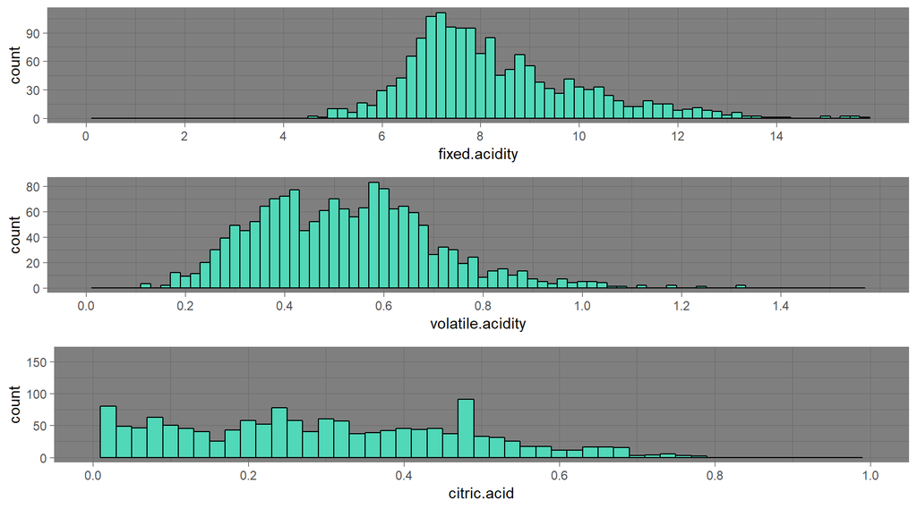

I explored acidity levels. Fixed acidity distribution is skewed to the right with few outliers after mark 14. Volatile acidity has a bi-modal distribution with lots of outliers after 1.1. The citric acid is uniformly distributed up to the point of 0.5. Where it doubles the number of occurrences and starts to  
vanish, till it gradually diminishes just before 1 mark. Fixed acid is a  
component of the wine. The large concentration of volatile acid can affect the taste of the wine, on another hand, citric acid can improve the wine tase.

### Alcohol, density, pH distribution

```
## [1] "Alcohol Statistics"
```

```
##    Min. 1st Qu.  Median    Mean 3rd Qu.    Max.
##    8.40    9.50   10.20   10.42   11.10   14.90
```

```
## [1] "Density Statistics"
```

```
##    Min. 1st Qu.  Median    Mean 3rd Qu.    Max.
##  0.9901  0.9956  0.9968  0.9967  0.9978  1.0037
```

```
## [1] "pH Statistics"
```

```
##    Min. 1st Qu.  Median    Mean 3rd Qu.    Max.
##   2.740   3.210   3.310   3.311   3.400   4.010
```

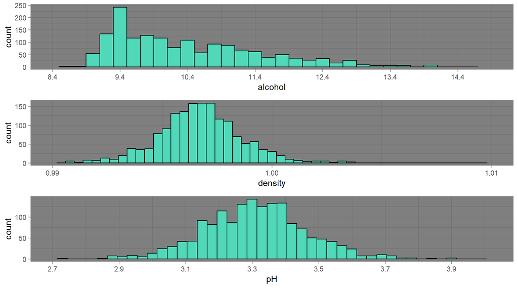

### Free sulfur dioxide and total sulfur dioxide distribution

```
## [1] "free.sulfur.dioxide Statistics"
```

```
##    Min. 1st Qu.  Median    Mean 3rd Qu.    Max.
##    1.00    7.00   14.00   15.87   21.00   72.00
```

```
## [1] "total.sulfur.dioxide Statistics"
```

```
##    Min. 1st Qu.  Median    Mean 3rd Qu.    Max.
##    6.00   22.00   38.00   46.47   62.00  289.00
```

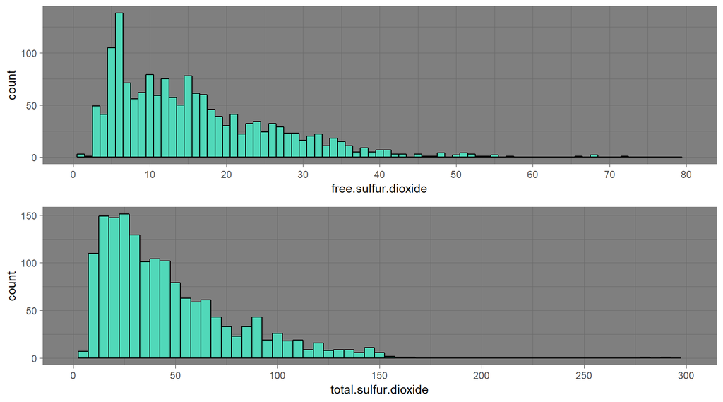

Both plots skewed to the right with outliers.

### Sulphates, residial.sugar, schlorides distribution

```
## [1] "Sulphates Statistics"
```

```
##    Min. 1st Qu.  Median    Mean 3rd Qu.    Max.
##  0.3300  0.5500  0.6200  0.6581  0.7300  2.0000
```

```
## [1] "residial.sugar Statistics"
```

```
##    Min. 1st Qu.  Median    Mean 3rd Qu.    Max.
##   0.900   1.900   2.200   2.539   2.600  15.500
```

```
## [1] "Schlorides Statistics"
```

```
##    Min. 1st Qu.  Median    Mean 3rd Qu.    Max.
## 0.01200 0.07000 0.07900 0.08747 0.09000 0.61100
```

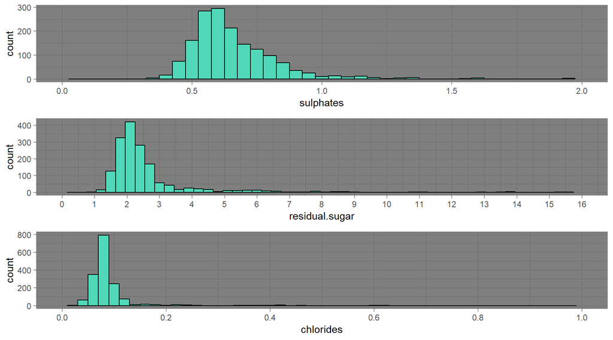

The plots skewed to the right with a large number of outliers.

### Quality categories

```
## [1] "Quality categories: "
```

```
##
##   3   4   5   6   7   8
##  10  53 681 638 199  18
```

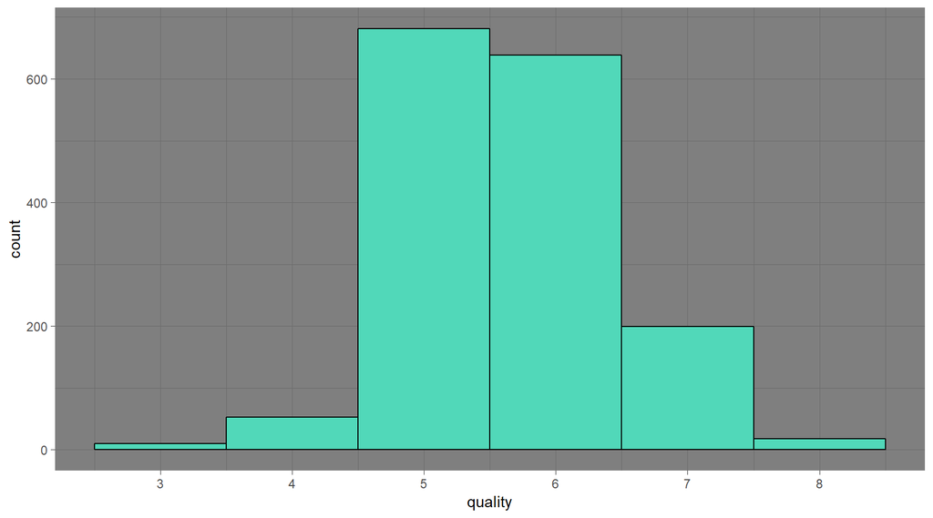

```
## [1] "quality = 5 and quality = 6"
```

```
## [1] 82.5
```

As can be seen from plot and table above, the majority of data represent the  
wine quality of 5 and 6. It is 82.5 %.

### Alcohol grouped by quality

In the next section of my project, I will explore the correlation between the  
two variables. Here, I want to group the distribution of some of the variables  
by quality. Intuitively, the alcohol level may differ by quality. I will plot the alcohol distribution to explore some patterns.

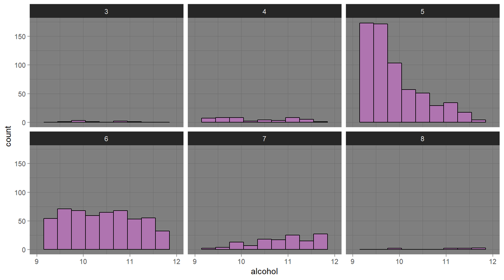

```
##
##   3   4   5   6   7   8
##  10  53 681 638 199  18
```

```
## data$quality: 3
##    Min. 1st Qu.  Median    Mean 3rd Qu.    Max.
##   8.400   9.725   9.925   9.955  10.575  11.000
## --------------------------------------------------------
## data$quality: 4
##    Min. 1st Qu.  Median    Mean 3rd Qu.    Max.
##    9.00    9.60   10.00   10.27   11.00   13.10
## --------------------------------------------------------
## data$quality: 5
##    Min. 1st Qu.  Median    Mean 3rd Qu.    Max.
##     8.5     9.4     9.7     9.9    10.2    14.9
## --------------------------------------------------------
## data$quality: 6
##    Min. 1st Qu.  Median    Mean 3rd Qu.    Max.
##    8.40    9.80   10.50   10.63   11.30   14.00
## --------------------------------------------------------
## data$quality: 7
##    Min. 1st Qu.  Median    Mean 3rd Qu.    Max.
##    9.20   10.80   11.50   11.47   12.10   14.00
## --------------------------------------------------------
## data$quality: 8
##    Min. 1st Qu.  Median    Mean 3rd Qu.    Max.
##    9.80   11.32   12.15   12.09   12.88   14.00
```

### Total total.sulfur.dioxide grouped by quality

```
##
##   3   4   5   6   7   8
##  10  53 681 638 199  18
```

```
## data$quality: 3
##    Min. 1st Qu.  Median    Mean 3rd Qu.    Max.
##     9.0    12.5    15.0    24.9    42.5    49.0
## --------------------------------------------------------
## data$quality: 4
##    Min. 1st Qu.  Median    Mean 3rd Qu.    Max.
##    7.00   14.00   26.00   36.25   49.00  119.00
## --------------------------------------------------------
## data$quality: 5
##    Min. 1st Qu.  Median    Mean 3rd Qu.    Max.
##    6.00   26.00   47.00   56.51   84.00  155.00
## --------------------------------------------------------
## data$quality: 6
##    Min. 1st Qu.  Median    Mean 3rd Qu.    Max.
##    6.00   23.00   35.00   40.87   54.00  165.00
## --------------------------------------------------------
## data$quality: 7
##    Min. 1st Qu.  Median    Mean 3rd Qu.    Max.
##    7.00   17.50   27.00   35.02   43.00  289.00
## --------------------------------------------------------
## data$quality: 8
##    Min. 1st Qu.  Median    Mean 3rd Qu.    Max.
##   12.00   16.00   21.50   33.44   43.00   88.00
```

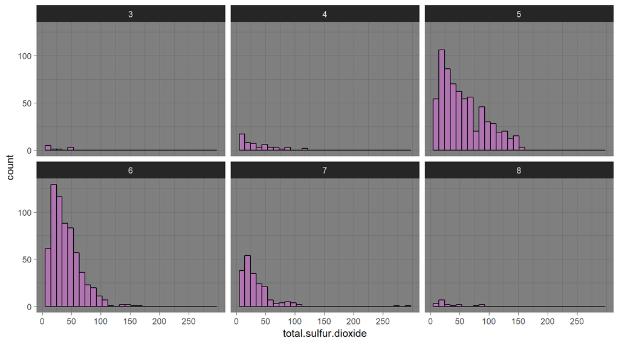

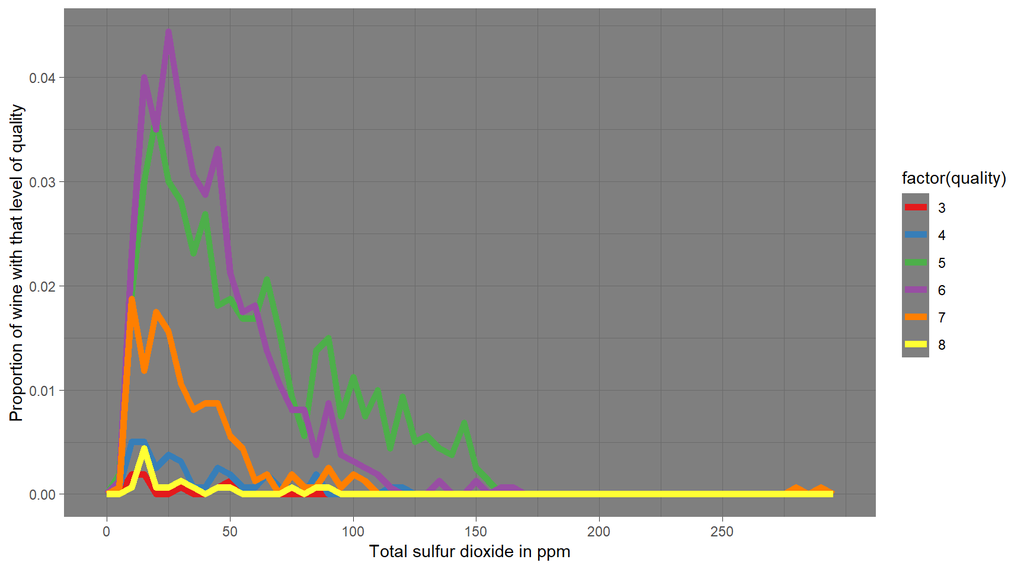

```
## [1] "total sulfur dioxide more than 50 ppm in Dataset"
```

```
##
## FALSE  TRUE
##  1053   546
```

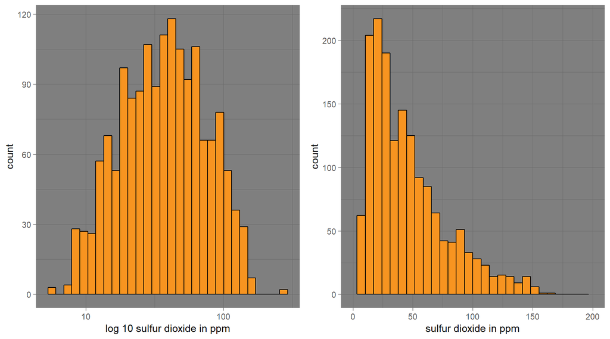

Total.sulfur.dioxide has positively skewed distribution with lots of outliers. I transformed values to Log10 to normalize the distribution.

# Univariate Analysis

### What is the structure of your dataset?

Data consists of 13 variables and 1599 samples. The data set is clean, doesn’t require any cleaning and has no missing value.

### What is/are the main feature(s) of interest in your dataset?

I am interested in finding a relationship between quality and other chemical attributes of the wine.

Even univariate exploration detected the relationship between quality and alcohol, quality and sulfur dioxide distribution.

### Did you create any new variables from existing variables in the dataset?

I didn’t create any new variables, due to the size of the dataset. I can always group_by variables for my data exploration’.

### Of the features you investigated, were there any unusual distributions?

I haven’t detected anything unusual but I believe that quality may be influenced by alcohol and total sulfur dioxide.

# Bivariate Plots Section

To determine which variables have the strongest correlation. I will print the correlation test and plot correlation matrix.

```
##                                 X fixed.acidity volatile.acidity
## X                     1.000000000   -0.26848392     -0.008815099
## fixed.acidity        -0.268483920    1.00000000     -0.256130895
## volatile.acidity     -0.008815099   -0.25613089      1.000000000
## citric.acid          -0.153551355    0.67170343     -0.552495685
## residual.sugar       -0.031260835    0.11477672      0.001917882
## chlorides            -0.119868519    0.09370519      0.061297772
## free.sulfur.dioxide   0.090479643   -0.15379419     -0.010503827
## total.sulfur.dioxide -0.117849669   -0.11318144      0.076470005
## density              -0.368372087    0.66804729      0.022026232
## pH                    0.136005328   -0.68297819      0.234937294
## sulphates            -0.125306999    0.18300566     -0.260986685
## alcohol               0.245122841   -0.06166827     -0.202288027
## quality               0.066452608    0.12405165     -0.390557780
##                      citric.acid residual.sugar    chlorides
## X                    -0.15355136   -0.031260835 -0.119868519
## fixed.acidity         0.67170343    0.114776724  0.093705186
## volatile.acidity     -0.55249568    0.001917882  0.061297772
## citric.acid           1.00000000    0.143577162  0.203822914
## residual.sugar        0.14357716    1.000000000  0.055609535
## chlorides             0.20382291    0.055609535  1.000000000
## free.sulfur.dioxide  -0.06097813    0.187048995  0.005562147
## total.sulfur.dioxide  0.03553302    0.203027882  0.047400468
## density               0.36494718    0.355283371  0.200632327
## pH                   -0.54190414   -0.085652422 -0.265026131
## sulphates             0.31277004    0.005527121  0.371260481
## alcohol               0.10990325    0.042075437 -0.221140545
## quality               0.22637251    0.013731637 -0.128906560
##                      free.sulfur.dioxide total.sulfur.dioxide     density
## X                            0.090479643          -0.11784967 -0.36837209
## fixed.acidity               -0.153794193          -0.11318144  0.66804729
## volatile.acidity            -0.010503827           0.07647000  0.02202623
## citric.acid                 -0.060978129           0.03553302  0.36494718
## residual.sugar               0.187048995           0.20302788  0.35528337
## chlorides                    0.005562147           0.04740047  0.20063233
## free.sulfur.dioxide          1.000000000           0.66766645 -0.02194583
## total.sulfur.dioxide         0.667666450           1.00000000  0.07126948
## density                     -0.021945831           0.07126948  1.00000000
## pH                           0.070377499          -0.06649456 -0.34169933
## sulphates                    0.051657572           0.04294684  0.14850641
## alcohol                     -0.069408354          -0.20565394 -0.49617977
## quality                     -0.050656057          -0.18510029 -0.17491923
##                               pH    sulphates     alcohol     quality
## X                     0.13600533 -0.125306999  0.24512284  0.06645261
## fixed.acidity        -0.68297819  0.183005664 -0.06166827  0.12405165
## volatile.acidity      0.23493729 -0.260986685 -0.20228803 -0.39055778
## citric.acid          -0.54190414  0.312770044  0.10990325  0.22637251
## residual.sugar       -0.08565242  0.005527121  0.04207544  0.01373164
## chlorides            -0.26502613  0.371260481 -0.22114054 -0.12890656
## free.sulfur.dioxide   0.07037750  0.051657572 -0.06940835 -0.05065606
## total.sulfur.dioxide -0.06649456  0.042946836 -0.20565394 -0.18510029
## density              -0.34169933  0.148506412 -0.49617977 -0.17491923
## pH                    1.00000000 -0.196647602  0.20563251 -0.05773139
## sulphates            -0.19664760  1.000000000  0.09359475  0.25139708
## alcohol               0.20563251  0.093594750  1.00000000  0.47616632
## quality              -0.05773139  0.251397079  0.47616632  1.00000000
```

```
##                             [,1]
## X                     0.06645261
## fixed.acidity         0.12405165
## volatile.acidity     -0.39055778
## citric.acid           0.22637251
## residual.sugar        0.01373164
## chlorides            -0.12890656
## free.sulfur.dioxide  -0.05065606
## total.sulfur.dioxide -0.18510029
## density              -0.17491923
## pH                   -0.05773139
## sulphates             0.25139708
## alcohol               0.47616632
## quality               1.00000000
```

The strongest relationship quality displays with alcohol and sulphates and the strongest negative are with volatile.acidity.

### Correlation Matrix Plot

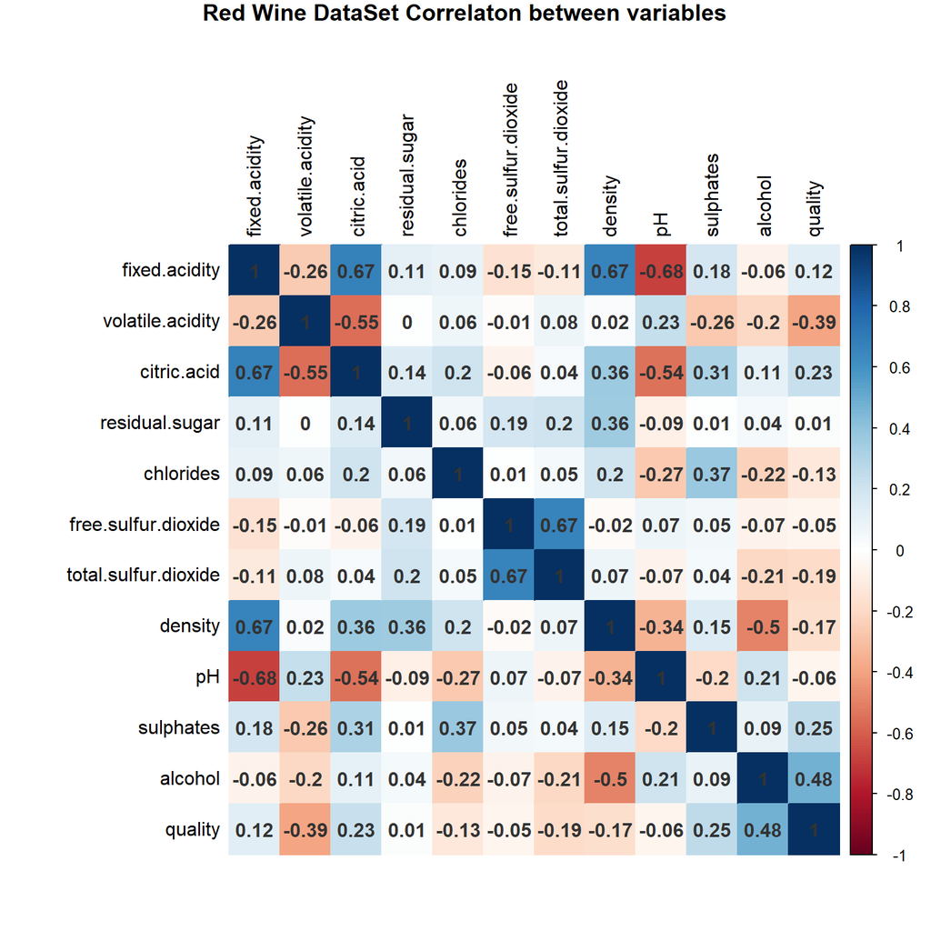

From this heat matrix, we can see that dioxides and acids have a relationship within their groups. Also as expected strong negative correlation present between pH and fixed.acidity and positive influence of fixed.acidity to density. I will selectively display some bivariate plots.

### Correlation Quality and Alcohol

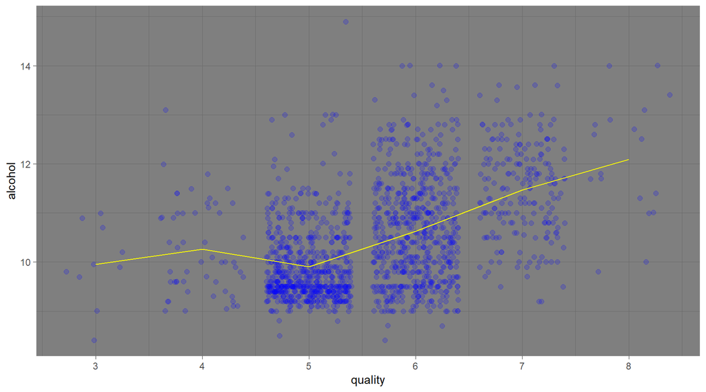

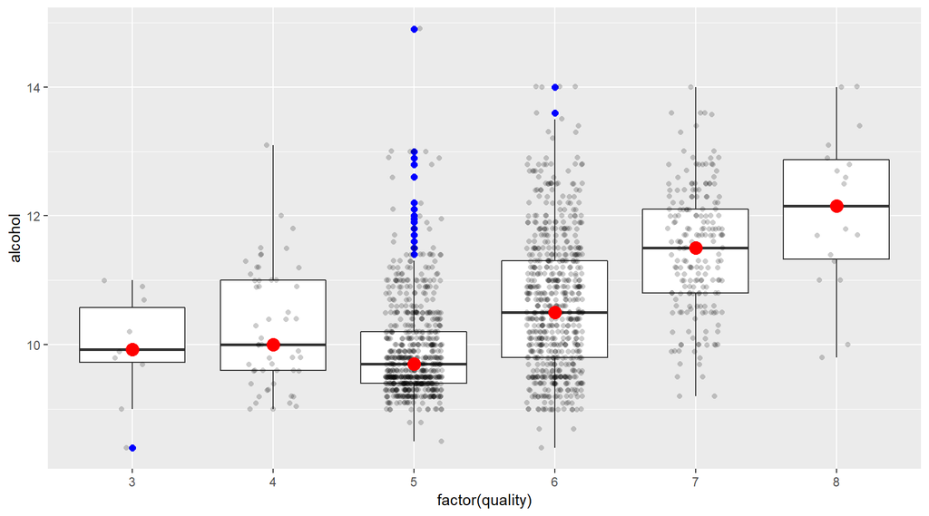

### Total.sulfur.dioxide and quality correlation

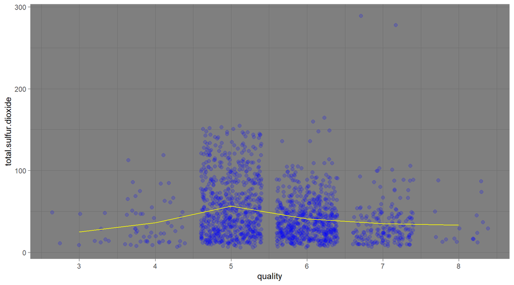

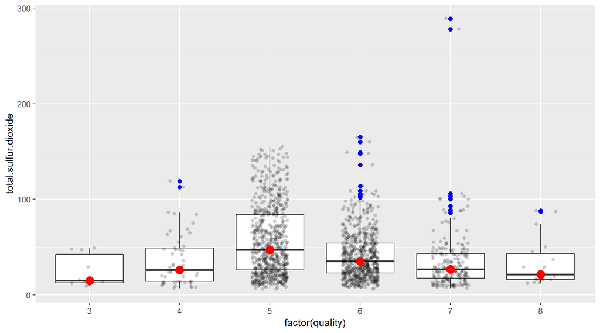

From correlation test and visualization total.sulfur.dioxide and quality correlation is equal to -0.18510029 and has little or no effect on wine quality.

### Total.sulfur.dioxide and alcohol

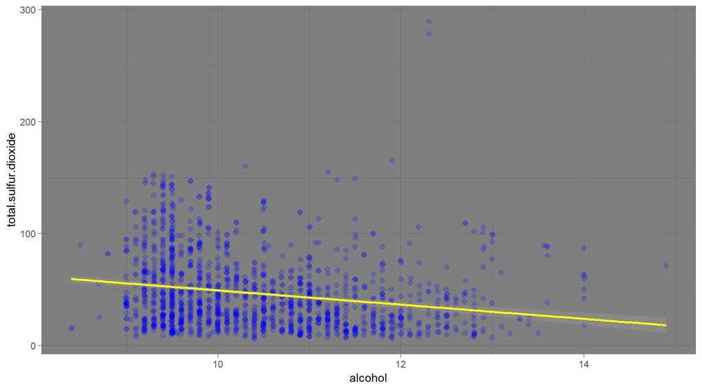

The plot above displays some negative correlation between total.sulfur.dioxide and alcohol. Alcohol has the biggest influence on quality. I will investigate further if there is a connection between all three attributes in the next section.

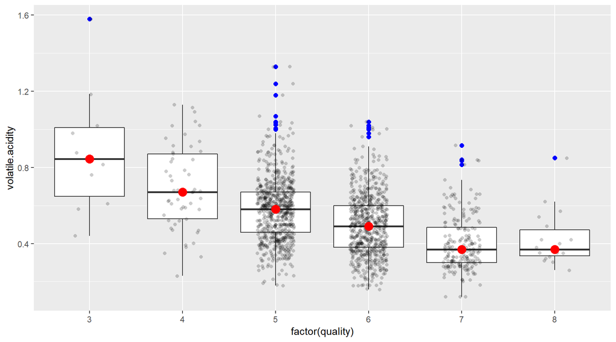

The meaningful negative relationship with quality represent volatile.acidity, the lower the level the better is the quality of the wine.

### Fixed.acidity correlaion

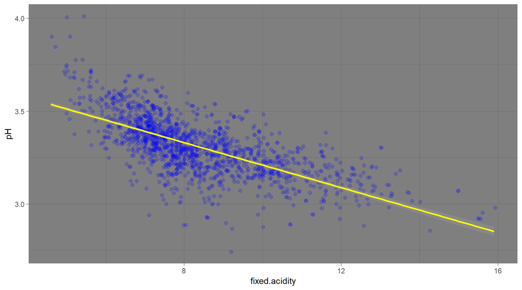

Fixed acidity displays negative correlation with pH

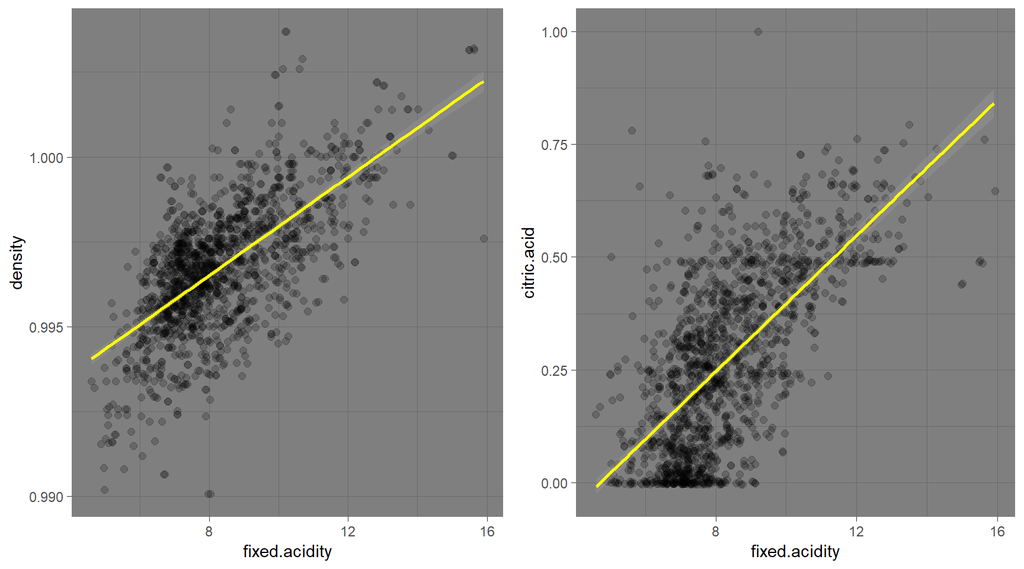

And positive correlation with density and citric acidity.

# Bivariate Analysis

From my univariate exploration, I was expecting to see a stronger connection between dioxids and quality.

Surprisingly dioxids have minimum effect on the quality of the wine, but has a negative effect on alcohol. On another side, sulphite is the second component playing a positive role in wine quality.

# Multivariate Plots Section

I have copied data to a new data frame data_1 and created three factor columns: - alcohol.level accordingly to [https://winefolly.com/tutorial/the-lightest-to-the-strongest-wine/] - quality.level. I divided the total.sulfur.dioxide by median value into two levels, to study more the effect of total.sulfur.dioxide on quality. - quality.level. To avoid overcrowding of plots, I rearranged quality factors into three, instead of 6.

### Scatterplot total.sulfur.dioxide, alcohol, quality

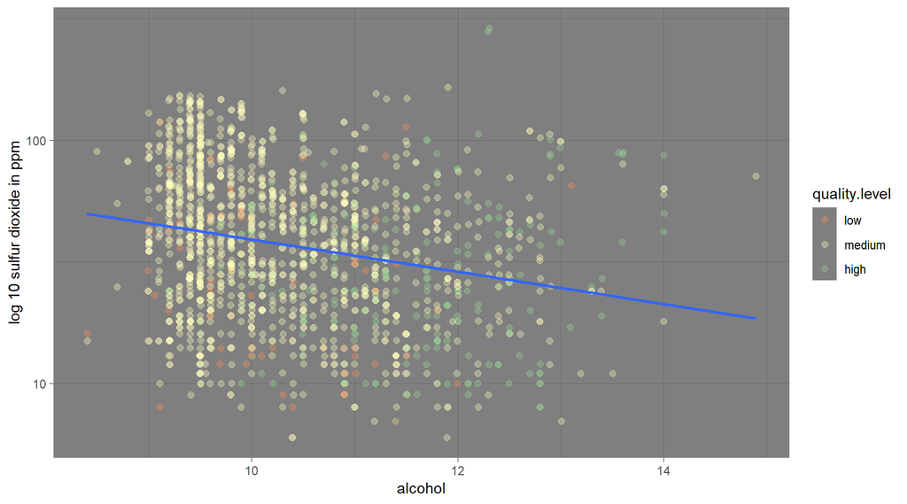

Following my previous analysis. I decided to check if there is any relationship between three variables, quality, alcohol and total.sulfur.dioxide. The above plot displays some visible pattern, as two main clusters: beige for mid-range and green for the top. Hence, we can draw some conclusion the better the quality, the higher the alcohol and the lower is total.sulfur.dioxide.

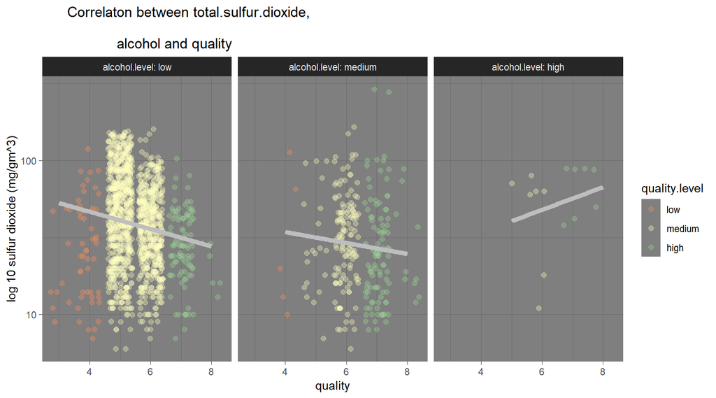

### Scatterplot pH, fixed.acidity, alcohol, quality

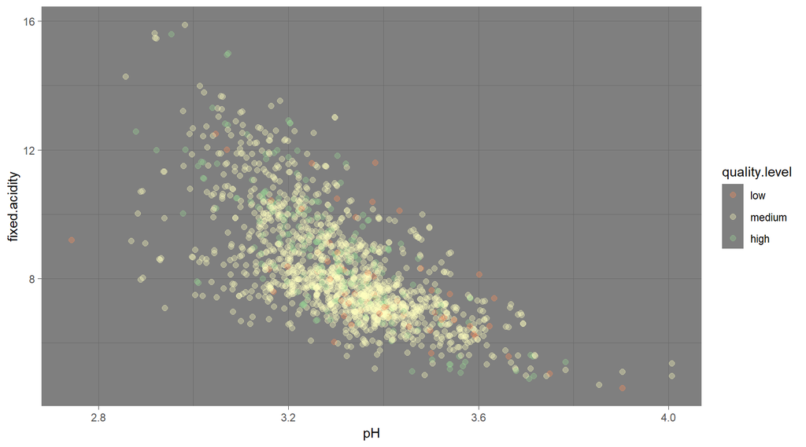

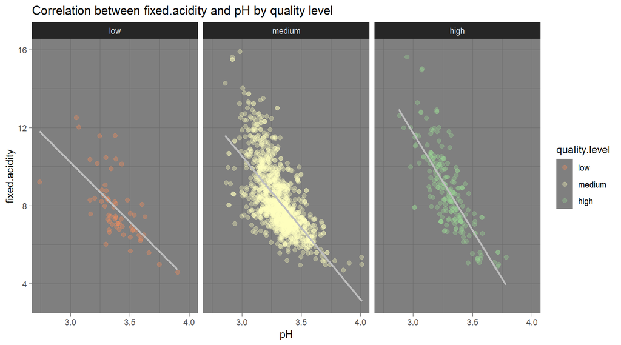

After I facet-wrapped by quality level, I haven’t noticed a big shift in data position, but observed improvement in the relationship between pH and fixed.acidity, it became almost linear.

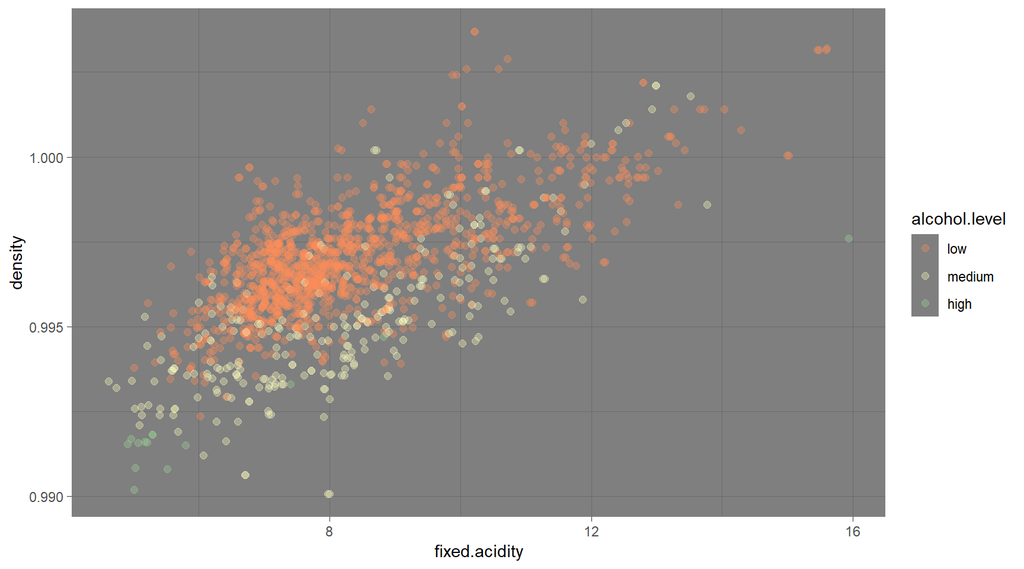

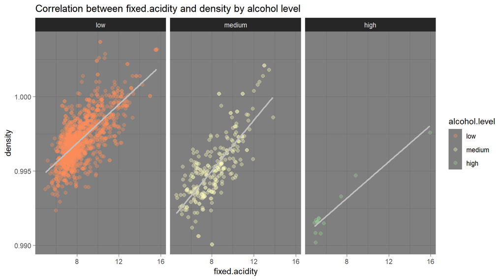

### Scatterplot pH, density and quality

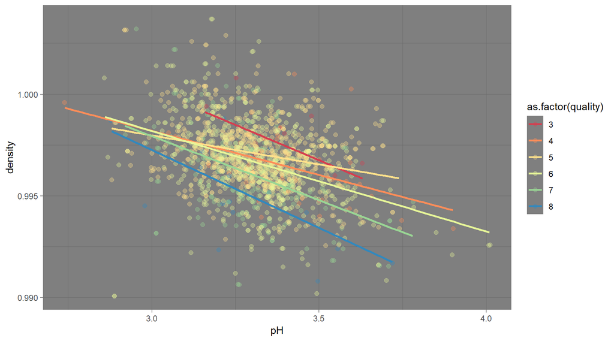

# Multivariate Analysis

### Talk about some of the relationships you observed in this part of the

investigation. Were there features that strengthened each other in terms of  
looking at your feature(s) of interest?

Quality is a prime feature shares with alcohol the highest correlation coefficient. While observing the correlation between all variables, I was very keen to find a relationship between total.sulfur.dioxide and quality. I wasn’t successful to determine direct strong correlation but was able to link it through alcohol. Higher grade wine is relatively tolerant to the amount of total.sulfur.dioxide, while mid-low-grade wine insists on a moderate level of total .sulfur.dioxide.

### Were there any interesting or surprising interactions between features?

# Final Plots and Summary

### Plot One

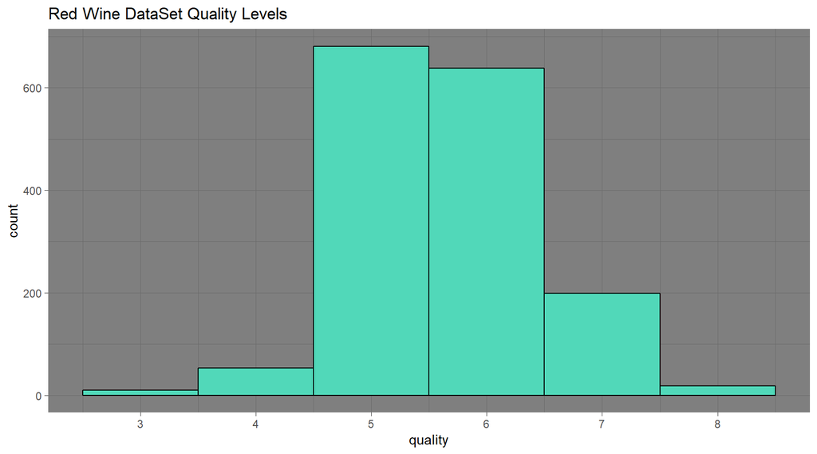

### Description One

This plot represents the distribution of the primary variable, quality. The majority of data, 82.5 % in this dataset is either in 5 or in 6 quality category.

### Plot Two

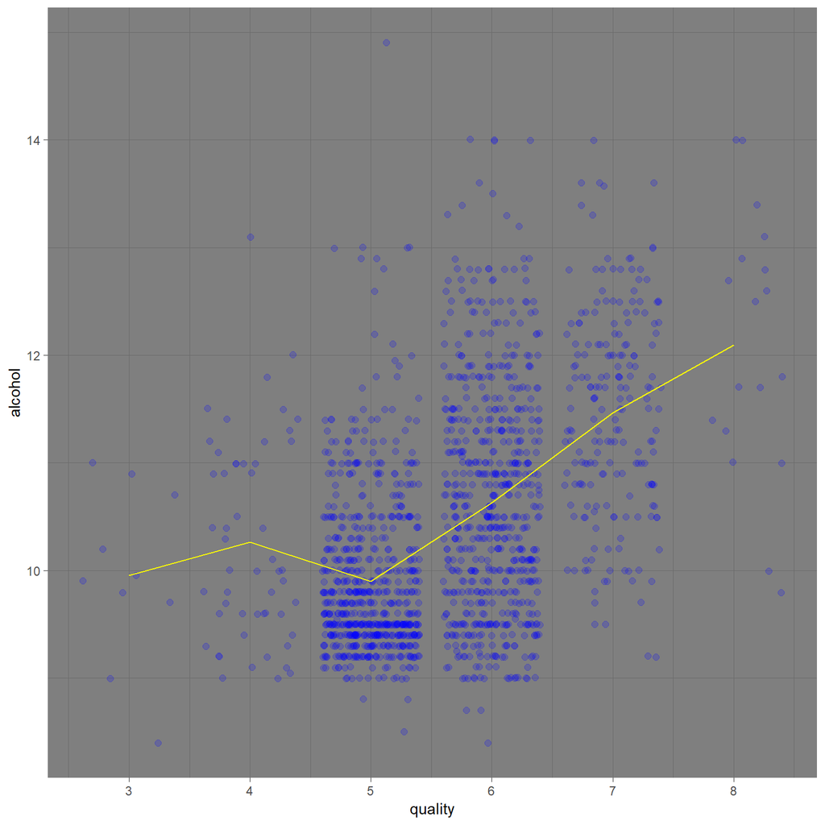

### Plot Three

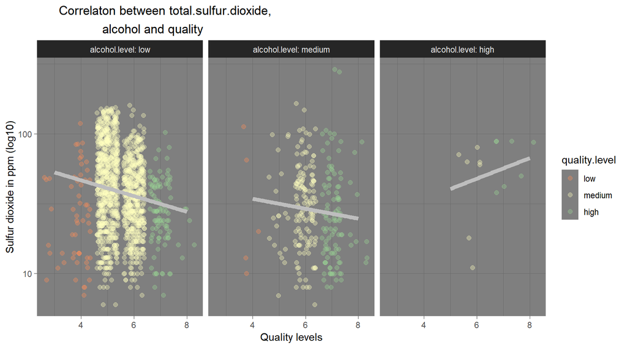

### Description Three

It can be studied from these plots, how the relationship changes between total sulfur dioxide and quality over the alcohol levels. The stronger the alcohol the better the tolerance to the sulfur dioxide by the quality. I was only able to detect the pattern after I transformed the positively skewed distribution of total sulfur dioxide to normally distributed, by applying log10.

# Reflection

The Red Wine Dataset has 1599 observations and 13 variables, however, most of the observations ( 82.5) fall between 5 and 6 quality levels, which may be biased to make a solid conclusion. However, based on my analysis. I can draw some insights: - The quality is a primary attribute and it is easier to start building connections with other variables from this point. - Quality and Alcohol have a meaningful correlation with the correlation coefficient of 0.48. - Still, the strongest positive correlations present withing acidic and dioxides groups, equal to 0.67. - Fixed acidity, has the strongest negative relationship with pH (-0.68).  
This could be expected from bipolar chemical properties. In general, none of the attributes displays very strong correlation.

For my research, I was interested to find a relationship between total sulfur dioxide and quality. Total sulfur dioxide is an important chemical element and plays an important role to preserve the wine, on another hand it can affect the quality of the wine if the concentration is higher than 50 ppm. Looking at the distribution of this property, I could see the change in mean and median values facet-wrapped by the quality levels. But, after bivariate analysis, I couldn’t draw any connection between quality and total sulfur dioxide. Only after conducting the multivariate analysis between quality, alcohol and total sulfur dioxide, I was able to detect the pattern in relation to the strength of alcohol and it is behaviour in different quality levels.

For my future project, I would like to work with a larger dataset to avoid the bias and to build a predictive model.

Refernces:

http://www.sthda.com/english/wiki/visualize-correlation-matrix-using-correlogram

https://support.rstudio.com/hc/en-us/articles/205175388-Using-the-Data-Viewer

http://ggplot.yhathq.com/docs/scale_color_brewer.html